# Introduction

### Finding the Minimum Energy Transition State (METS)

```python
# To find the METS, the function get_mets() goes through all sources with the target state (target_state).
# - For sources defined in a singlet state, it verifies that it is a TS (one sizeable negative frequency)
# - For sources defined as a triplet, it verifies that it is a minimum (all frequencies are positive, or almost).
#   Also, it applies an energy penalty to Gtot, to compensate for the ISC processes.

#   This penalty is applied as dE = - RT ln(p_sh)
#    - where p_sh is the probability of surface hopping.
#   By default, p_sh is set to 0.0002, so dE amounts 5 kcal/mol at 298.15 K.
#   This value is a parameter, and can be modified by the user.

## Finally, it selects and returns the source with a lowest Gtot at the requested temperature (temp). That is, the METS
mets = sys.get_mets(temp=298.15, target_state='opt', force=True, p_sh=0.0002)
```

```python
## In this case, the METS is a structure associated with a rotation in the triplet surface
print(mets)
```

```
---------------------------------------
------ SCOPE Molecule_azo Object ------
---------------------------------------
 Version               = 1.0
 Type                  = specie
 Sub-Type              = molecule_azo
 Name                  = tsrot_a_t
 Number of Atoms       = 24
 Formula               = H8-C12-N2-Cl2
 Charge                = 0
 Spin (alpha - beta)   = 2
 Number of Parents     = 0
 Has Adjacency Matrix  = NO
 Has Bonds             = NO
-------------------------------------------------
 Main Geometry Features of the Azo group:
-------------------------------------------------
 NN distance (dNN):         1.2446
 Left Inv. Angle (CNN):     113.8583
 Right Inv. Angle (NNC):    114.9822
 Main Dihedral (CNNC):      90.0
 Adj Dihedral Left (CCNN):  6.7616
 Adj Dihedral Right (NNCC): -0.0
```

```python
## The Geometry Features shown above refer to the SOURCE in its INITIAL state. To see those values in the computed target_state (opt), we need to load it:
found, mets_opt_state = mets.find_state("opt")
print(mets_opt_state)
```

```
------------------------------------
------ SCOPE State_azo Object ------
------------------------------------
 Name                  = opt
 Source Name           = tsrot_a_t
 Source Type           = specie
 Labels                = C...
 Coord                 = [-0.173125, -1.044504, -0.658308]...
 Number of Units (Z)   = 1

 Has VNMs              = YES
 Is Minimum            = True
 Is a Transition State = False
 First Freq (cm-1)     = 19.8729

 Num of Molecules:     = 1
 With Formulae:
    0: H8-C12-N2-Cl2
-------------------------------------------------
 Main Geometry Features of the Azo group:
-------------------------------------------------
 NN distance (dNN):         1.2661
 Left Inv. Angle (CNN):     127.971
 Right Inv. Angle (NNC):    128.0156
 Main Dihedral (CNNC):      110.9285
 Adj Dihedral Left (CCNN):  -11.9885
 Adj Dihedral Right (NNCC): -11.8401
```

#### Gtot vs. Gtot_eff

```python
## Beyond geometry, this state is associated with a Gtot value at 298.15K.
## This value includes vibrational and electronic enthalpy and entropy terms, as discussed in Tutorial 4.
## This are automatically computed during sys.get_mets(), and stored appropriately as State results for each Isomer (cis, trans, ts...)
Gtot_eff = mets_opt_state.results['Gtot_eff']

## Technically, Gtot is an instance of the Collection-class:
print(Gtot_eff)
```

```
---------------------------------------------------
   COLLECTION OF DATA   = Gtot_eff
---------------------------------------------------
 Variable              = temperature
 Num of Entries        = 1
 First                 = -1490.8317518596448
 Last                  = -1490.8317518596448
 Units                 = au
 Function              = state_azo.get_gtot_eff()
```

```python
## Collections store multiple values associated with the same variable (here, Gtot) but under different circumstances (e.g. temperature).
## To find the Gtot value at a specific temperature, you can do:
print(Gtot_eff.find_value_with_property('temperature', 298.15))
```

```
Gtot_eff: -1490.83175186 au (at temperature=298.15)
```

```python
# The name 'Gtot_eff' means that any energy penalty has already been considered.
# In this case, since the METS is a triplet, Gtot_eff differs from the 'original' (i.e. without penalty) Gtot
Gtot = mets_opt_state.results['Gtot'].find_value_with_property('temperature', 298.15)
print(Gtot)
## Notice the slight difference in energy...
```

```
Gtot: -1490.83979360 au (at temperature=298.15)
```

```python
## This difference in energy corresponds to the energy penalty associated with the triplet states
diff = Gtot - Gtot_eff.find_value_with_property('temperature', 298.15)
diff.convert_to_units('kcal')

## In singlet states, Gtot and Gtot_eff should be equal
```

```
sum_Gtot:  -5.04627077 kcal
```

### Halflife time

```python
## Overall, with the METS energy, and that of the Trans isomer, one can get obtain the rate constant (k) and the halflife time (t05) of each isomer:
sys.get_cis_halflife_time(temp=298.15, debug=0)
```

```
cis_halflife_time: 264.61534987 s (at temperature=298.15)
```

```python
# The halflife time is stored as a result for this system:
print(sys.results['cis_halflife_time'])

# Together with the thermal relaxation rate
print(sys.results['rate_thermal_cis2trans'])

# and the dG=(G_TS - G_cis)
print(sys.results['dG_from_cis'])
```

```
cis_halflife_time: 264.61534987 s (at temperature=298.15)
rate_thermal_cis2trans:   0.00261945 s^-1 (at temperature=298.15)
dG_from_cis:  20.97520978 kcal/mol (at temperature=298.15)
```

```python
## This is also possible for the trans isomer:
sys.get_trans_halflife_time(temp=298.15, debug=0)
```

```
trans_halflife_time: 105897.54166269 s (at temperature=298.15)
```

## Part 3. Optical Properties

```python
# Apart from the cis-trans thermal stability, one of the key properties of Azo complexes is their light-absorption profile.
# For the test compound, the absorption spectrum is simulated using the excited states data obtained from TD-DFT.
# Here, this data is stored in the 'opt' state.
found, trans_source = sys.find_source('trans')
found, trans_state  = trans_source.find_state('opt')
print(trans_state)
```

```
------------------------------------
------ SCOPE State_azo Object ------
------------------------------------
 Name                  = opt
 Source Name           = trans
 Source Type           = specie
 Labels                = C...
 Coord                 = [-0.031101, -0.036525, 0.03185]...
 Number of Units (Z)   = 1

 Has VNMs              = YES
 Is Minimum            = True
 Is a Transition State = False
 First Freq (cm-1)     = 17.3076

 Has Excited States    = YES
 Num of Molecules:     = 1
 With Formulae:
    0: H8-C12-N2-Cl2
-------------------------------------------------
 Main Geometry Features of the Azo group:
-------------------------------------------------
 NN distance (dNN):         1.2372
 Left Inv. Angle (CNN):     115.3575
 Right Inv. Angle (NNC):    115.3682
 Main Dihedral (CNNC):      179.9971
 Adj Dihedral Left (CCNN):  42.0511
 Adj Dihedral Right (NNCC): -42.1224
```

```python
# The excited states are stored as an attribute:
trans_state.exc_states
```

```
[-------------------------------------------
  Index                  = 1
  Energy (eV)            = 2.6097 eV
  Wavelength (nm)        = 475.08 nm
  Oscillator Strength    = 0.0,
 -------------------------------------------
  Index                  = 2
  Energy (eV)            = 4.3288 eV
  Wavelength (nm)        = 286.42 nm
  Oscillator Strength    = 0.3999,
 -------------------------------------------
  Index                  = 3
  Energy (eV)            = 4.6914 eV
  Wavelength (nm)        = 264.28 nm
  Oscillator Strength    = 0.0,
 -------------------------------------------
  Index                  = 4
  Energy (eV)            = 4.8376 eV
  Wavelength (nm)        = 256.29 nm
  Oscillator Strength    = 0.1448,
 -------------------------------------------
  Index                  = 5
  Energy (eV)            = 5.4584 eV
  Wavelength (nm)        = 227.14 nm
  Oscillator Strength    = 0.0,
 -------------------------------------------
  Index                  = 6
  Energy (eV)            = 5.5735 eV
  Wavelength (nm)        = 222.45 nm
  Oscillator Strength    = 0.0698,
 -------------------------------------------
  Index                  = 7
  Energy (eV)            = 5.6879 eV
  Wavelength (nm)        = 217.98 nm
  Oscillator Strength    = 0.0,
 -------------------------------------------
  Index                  = 8
  Energy (eV)            = 5.7268 eV
  Wavelength (nm)        = 216.5 nm
  Oscillator Strength    = 0.0693,
 -------------------------------------------
  Index                  = 9
  Energy (eV)            = 6.0569 eV
  Wavelength (nm)        = 204.7 nm
  Oscillator Strength    = 0.0,
 -------------------------------------------
  Index                  = 10
  Energy (eV)            = 6.1227 eV
  Wavelength (nm)        = 202.5 nm
  Oscillator Strength    = 0.2264]
```

### Absorption Spectrum

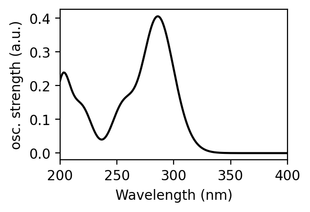

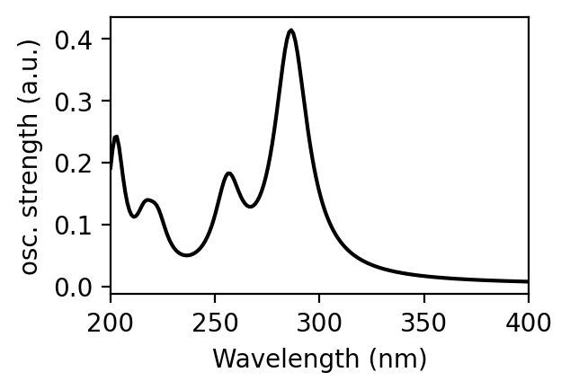

```python
# Alltogether, they generate the absorption spectrum
trans_state.plot_abs_spectrum(lmin=200, lmax=400, function='gaussian', sigma=0.2)

# Alternatively, if you prefer the spectrum as x, y arrays, you can run:
# x, y = trans_state.get_abs_spectrum(lmin=200, lmax=400, function='gaussian', sigma=0.2)

# In both cases, we selected gaussian functions with sigma=0.2 for the convolution.
# Lorentzian and Laplacian functions can be used instead, as well as other sigma values
trans_state.plot_abs_spectrum(lmin=200, lmax=400, function='lorentzian', sigma='auto')
```

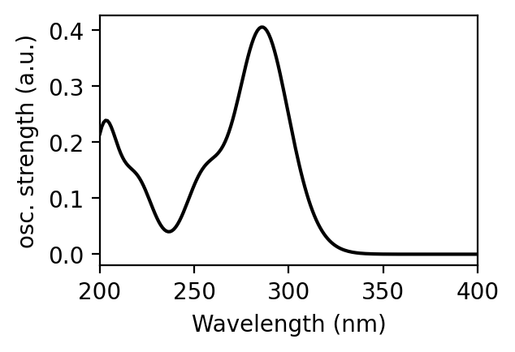

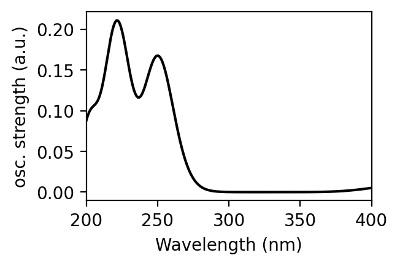

```python
# Of course, the same holds for the 'cis' isomer:
found, cis_source = sys.find_source('cis')
found, cis_state  = cis_source.find_state('opt')
trans_state.plot_abs_spectrum(lmin=200, lmax=400, function='gaussian', sigma=0.2)
cis_state.plot_abs_spectrum(lmin=200, lmax=400, function='gaussian', sigma=0.2)
```

### The Photo-Stationary State (PSS)

Under light irradiation, azo molecules reach a **photostationary state (PSS)** in which both the trans (E) and cis (Z) isomers are populated. The final composition depends on the competition between **thermal relaxation** and **photo-induced isomerization** processes.

Starting from the steady-state condition:

$$ \displaystyle \frac{d[E]}{dt} = - (k^{ph}_{EZ} + k^{th}_{EZ}) [E] + (k^{ph}_{ZE} + k^{th}_{ZE}) [Z] = 0 $$

Then,

$$ \displaystyle k_{EZ}[E] = k_{ZE}[Z] $$

Within this framework, the fraction -population- of the E isomer under irradiation ($N_E$) can be written as:

$$ \displaystyle N_E = \frac{k_{ZE}}{k_{EZ} + k_{ZE}} =\frac{k^{th}_{ZE} + k^{ph}_{ZE}} {k^{th}_{EZ} + k^{ph}_{EZ} + k^{th}_{ZE} + k^{ph}_{ZE}}; \quad $$$$ N_Z = 1- N_E $$

where $k^{th}_{EZ}$ and $k^{th}_{ZE}$ elements are the **thermal rate constants** for the conversion from trans to cis (EZ) and cis to trans (ZE) while $k_{EZ}^{ph}$ and $k_{ZE}^{ph}$ are the **photoisomerization rate constants**.

The **thermal rates $k^{th}_{EZ}$ and $k^{th}_{ZE}$** are normally evaluated using Eyring equation, or obtained from experimental half-life times, $t_{1/2}$ assuming a first-order reaction:

$$k^{th} = \frac{ln(2)}{t_{1/2}} \quad [s^{-1}]$$

The **photochemical rates $k^{ph}_{EZ}$ and $k^{ph}_{ZE}$** can be modeled as

$$ \displaystyle k^{ph}_{EZ} = \phi_{EZ} \int \sigma_E(\lambda)\,\Phi(\lambda)\, d\lambda \quad [s^{-1}] $$

by combining three physical quantities:

- the **absorption probability** of the molecule (or absorption cross section): $\sigma_E(\lambda)$   [$m^2$]
- the **number of incoming photons** (or photon flux): $\Phi(\lambda)$              [$photons·m^{-2} s^{-1} nm^{-1}$]
- the **probability that absorption leads to reaction** (or quantum yield): $\phi_{EZ}$      [$a.u$]

More specifically:

- $\Phi(\lambda)$ represents the number of photons reaching the sample per unit area, per unit time, and per wavelength interval. It is obtained from the irradiance divided by the energy of a single photon:

$$ \Phi(\lambda) = \frac{I(\lambda)}{E_{photon}}; \quad \frac{\left[\frac{J}{s·m^2 nm^{-1}}\right]}{\left[ J \right]} $$

- $\sigma_E(\lambda)$ quantifies the probability that a molecule absorbs a photon of wavelength $\lambda$. **Note:** *The spectra obtained by using get_abs_spectrum() returns the oscillator strengths vs. wavelength, $f(\lambda)$. To provide physical meaning (by converting it to an absorption cross section), the y-axis is converted to* $m^2$ *by applying a factor K (note that a $s^{-1}$ should appear, and it is cancelled by frequency units implicit in the wavelength space):*

$$ \sigma_E(\lambda) = \frac{\pi · h · e}{ \varepsilon _0 · m_e · c } * f(\lambda) \quad \left[ m^2 \right] $$

- $\phi_{ZE}$ measures the efficiency of the photochemical reaction. It corresponds to the fraction of absorbed photons that result in isomerization (for example, $\phi_{ZE}=0.5$ means that half of the absorbed photons lead to reaction).

In practice, light sources are not perfectly monochromatic (even lasers emit photons across a finite wavelength range). For this reason, contributions from all wavelengths must be considered, which is achieved through the integral above. The resulting equation corresponds to the **total absorption rate per molecule** and can be interpreted as a spectral overlap between the lamp emission spectrum and the molecular absorption spectrum.

Once the populations in the steady state, and $N_E$,$N_Z$ at an given irradiation wavelength are known, it is possible to obtain PSS absorption cross section spectrum $$ \displaystyle \sigma_{PSS}(\lambda) = N_E \sigma_{E}(\lambda)+ N_Z \sigma_{Z}(\lambda) $$

along with the molar absorptivity, $\varepsilon$ in $L · mol^{-1}·cm^{-1}$, applying the Lambert-Beer concentration factors

$$ \displaystyle \varepsilon_{PSS}(\lambda) = \frac{N_A}{1000 · ln(10)} \sigma_{PSS}(\lambda) $$

Then, the molar absorptivity at the steady state can be represented graphically for each irradiation wavelength $\displaystyle \varepsilon_{PSS}(\lambda)$ vs. $\lambda$.

#### The 'Lamp' Class

```python
from scope_azo.azo_classes import Lamp
```

```python
# The properties of the light source are provided to the PSS as a Lamp-Class object.
# Lamps store information about the available wavelengths, and associated FWHM and Power values.
# If you don't have such information, you can use a "default" Lamp that we provide within SCOPE.
# Any Lamp can be tuned at will by the user, and new Lamps can also be added as simple JSON files.
my_lamp = Lamp("default")
print(my_lamp)
```

```
--------- Scope Lamp Object -----------
 Name             = default
 Wavelengths      = [  0 250 280 310 340 370 400 430 460 490 520 550 580] nm
 FWHM             = [ 1. 20. 20. 20. 20. 20. 20. 20. 20. 20. 20. 20. 20.] nm
 Power            = [ 0. 50. 50. 50. 50. 50. 50. 50. 50. 50. 50. 50. 50.] mW
 Power Intensity  = 1.0
---------------------------------------
```

```python
# Basically, this Lamp provides 12 excitation wavelentghs defined as:
# - gaussians of FWHM=20 nm
# - with 50 mW of power when used at 100% (Power Intensity=1.0). Can be changed with my_lamp.set_power_intensity()
```

```python
# For the moment, only one real-world device has been included, the CoolLED pE-4000:
my_lamp = scope_azo.azo_classes.Lamp("coolled")
print(my_lamp)
```

```
--------- Scope Lamp Object -----------
 Name             = coolled
 Wavelengths      = [  0 365 385 405 435 460 470 500 525 550 595 635 660 740 770] nm
 FWHM             = [ 1.   12.54 11.38 16.08 13.02 17.61 23.26 24.72 28.32 82.79 14.61 16.72
 21.42 41.12 27.75] nm
 Power            = [  0.    15.12  59.39 188.32 138.75 240.19 192.29  59.26  39.   166.74
  32.52 123.88 159.01  36.62  15.61] mW
 Power Intensity  = 1.0
---------------------------------------
```

```python
# Finally, absence of irradiation can be simulated with the "dark" Lamp:
my_lamp = scope_azo.azo_classes.Lamp("dark")
print(my_lamp)
```

```
--------- Scope Lamp Object -----------
 Name             = dark
 Wavelengths      = [0] nm
 FWHM             = [1.] nm
 Power            = [0.] mW
 Power Intensity  = 0.0
---------------------------------------
```

```python
# To compute the PSS, one just needs to use the get_PSS() function as:
my_pss = sys.get_PSS(lamp_name='default', target_state='opt', temp=298.15, lmin=200, lmax=600)

# This function has several options and defaults, do not forget to read the docs if necessary:
#help(sys.get_PSS)

# In summary, the function takes/computes all relevant data from the stored sources (trans, cis), and creates a PSS-class instance:
print(my_pss)

# This class stores relevant data to compute the PSS at any given wavelength, such as the thermal rates.
```

```
------------------------------
   >>> SCOPE PSS Object >>>
------------------------------
 System             = test
 Lamp Name          = default
 Lamp Wavelengths   = [  0 250 280 310 340 370 400 430 460 490 520 550 580] (nm)
 Lamp FWHM          = [ 1. 20. 20. 20. 20. 20. 20. 20. 20. 20. 20. 20. 20.] (nm)
 Lamp Powers        = [ 0. 50. 50. 50. 50. 50. 50. 50. 50. 50. 50. 50. 50.] (mW)
 Illuminated Area   = 78.539816 (mm2)
 Rate Thermal E->Z  = 6.545451e-06 (s^-1)
 Rate Thermal Z->E  = 2.619452e-03 (s^-1)
 Num of Results     = 13
```

```python
# Wavelength-dependent results are stored as a dictionary, with wavelengths as keys:
res = my_pss.pss_results[250]

print(res['wavelength'])                ## Wavelength of irradiation
print(res['pss_trans_ratio'])           ## Ratio of Trans Isomer in the PSS
print(res['rate_photo_trans2cis'])      ## Photoisomerization Rate for E-->Z at this wavelength
print(res['rate_photo_cis2trans'])      ## Photoisomerization Rate for Z-->E at this wavelength
print(res['rate_thermal_trans2cis'])    ## Thermal Reaction Rate for E-->Z (independent of wavelength)
print(res['rate_thermal_cis2trans'])    ## Thermal Reaction Rate for Z-->E (independent of wavelength)
print(res['QY_trans2cis'])              ## Quantum Yield for E-->Z photoisomerization at this wavelength
print(res['QY_cis2trans'])              ## Quantum Yield for Z-->E photoisomerization at this wavelength
```

```
250
0.6792281181392162
0.01352218580838394
0.026027369078849585
6.5454510999680045e-06
0.0026194518983660817
0.3
0.5
```

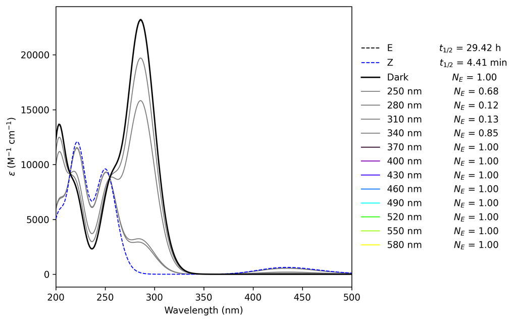

```python
# Results can be plotted with:
my_pss.plot_spectra(lmax=500)
```

```python
# Above, we can see that we only obtain a mixture of E and Z isomers under light between 250-340 nm.
# For all other cases, only the trans state is present

# These are, unfortunately, boring results from the physico-chemical point of view.
```

## Part 4. Creating new Azo-based Systems

Here we show how to create a new system from scratch, and feed it with **sources**. All steps should proceed seamlessly if you follow the instructions shown below.

```python
# First, let's define a SMILES string. It is important to be careful when
#   constructing your SMILES: it MUST follow the pattern below to correctly detect
#   atom indices near the Azo group, enabling rotation and inversion of both rings.

#   IMPORTANT: SMILES strings MUST adhere to the following structure:
#                    'C1(...C1)/N=N/ring2'
#                              or
#                    'C1(...C1)/N=N\\ring2'
#
#              That is, it doesn't matter if the SMILES string is in trans (../N=N/..) or cis (../N=N\..).
#              However, there is a specific way to define both rings. See below for an example.

# We will select azobenzene for its simplicity. Let's store the SMILES string and its name.

smiles  = 'c1(ccccc1)/N=N\\c2ccccc2'
name    = 'Azobenzene'
```

```python
# We will create our system as a System_azo object providing its name and the smiles.
new_sys = scope_azo.System_azo(name, smiles)
print(new_sys)
```

```
-------------------------------------
   >>> SCOPE System_azo Object >>>
-------------------------------------
 Name                  = Azobenzene
 Dihedral Indices:     = [1, 0, 6, 7, 8, 9]
 Version               = 1.0
 Type                  = system
 Subtype               = system_azo
---------------------------------------------
```

### Creating E, Z and TS

```python
# System_azo.create_trans()
    # Creates trans structures.
    # It uses the SMILES string stored in the System to generate 3D coordinates.
    # If everything works, it adds the trans isomer as a `Molecule_azo` object as source of the system
    # Returns the `Molecule_azo` object.
```

```python
# Let's create the trans isomer. It is automatically registered as a source in our azobenzene system.
# Note that the 'overwrite' parameter defaults to False.
trans = new_sys.create_trans(overwrite=True)
print(trans)

# If Openbabel is not installed, it will raise and error. Install it with 'conda install openbabel -c conda-forge'
```

```
---------------------------------------
------ SCOPE Molecule_azo Object ------
---------------------------------------
 Version               = 1.0
 Type                  = specie
 Sub-Type              = molecule_azo
 Name                  = trans
 Number of Atoms       = 24
 Formula               = H10-C12-N2
 Charge                = 0
 Spin (alpha - beta)   = 0
 SMILES                = c1(ccccc1)/N=N/c2ccccc2
 Number of Parents     = 0
 Has Adjacency Matrix  = NO
 Has Bonds             = NO
-------------------------------------------------
 Main Geometry Features of the Azo group:
-------------------------------------------------
 NN distance (dNN):         1.251
 Left Inv. Angle (CNN):     112.6651
 Right Inv. Angle (NNC):    114.0996
 Main Dihedral (CNNC):      173.1404
 Adj Dihedral Left (CCNN):  -178.177
 Adj Dihedral Right (NNCC): 143.5666
```

```python
# System_azo.create_cis(target_deg=40.)
    # Creates cis structures from the trans isomer. if the trans isomer is not created, then it is also created.
    # If everything works, it adds the cis isomer as source of the system.
    # The `target_deg` parameter allows you to choose the torsion of the dihedral angle of the Azo group (CN=NC).
    # By default, it is set to 40.0 degrees.
cis = new_sys.create_cis(target_deg=30.)
print(cis)
```

```
---------------------------------------
------ SCOPE Molecule_azo Object ------
---------------------------------------
 Version               = 1.0
 Type                  = specie
 Sub-Type              = molecule_azo
 Name                  = cis
 Number of Atoms       = 24
 Formula               = H10-C12-N2
 Charge                = 0
 Spin (alpha - beta)   = 0
 SMILES                = c1(ccccc1)/N=N\c2ccccc2
 Number of Parents     = 0
 Has Adjacency Matrix  = NO
 Has Bonds             = NO
-------------------------------------------------
 Main Geometry Features of the Azo group:
-------------------------------------------------
 NN distance (dNN):         1.251
 Left Inv. Angle (CNN):     112.6651
 Right Inv. Angle (NNC):    114.0996
 Main Dihedral (CNNC):      30.0
 Adj Dihedral Left (CCNN):  -151.0
 Adj Dihedral Right (NNCC): 168.0
```

### Creation of transition states

```python
# System_azo.create_ts(ts_list=['tsrot', 'tsinv', 'triplet'])
#
#   The `ts_list` parameter allows you to specify which (TS) structures will be generated:
#
# - tsrot: Generates the rotation of the azo group. It creates two
#   structures in the singlet state with the central C-N=N-C dihedral
#   angle set to +90 deg (TSrot_a_s) and -90 deg (TSrot_b_s).
#
# - tsinv_l & tsinv_r: Generates the left (tsinv_l) and right (tsinv_r) inversion TS.
#     * The angle of the inverting nitrogen (C-N=N for the left
#       ring, or N=N-C for the right ring) is changed to 180 deg.
#     * Each type of inversion (r and l) creates two variants (a and b),
#       indicating that the adjacent dihedral is set to 0 and 180 deg, respectively (tsinv_r_a and tsinv_r_b).
#
# - triplet: If included, this flag also generates the rotational
#   transition states (tsrot) in the triplet state (spin = 2)
#
# By default, all are generated
```

```python
# Following the naming convention above:
ts_list = new_sys.create_ts()
print([ts.name for ts in ts_list])
```

```
['tsrot_a_s', 'tsrot_a_t', 'tsrot_b_s', 'tsrot_b_t', 'tsinv_l_a', 'tsinv_l_b', 'tsinv_r_a', 'tsinv_r_b']
```

```python
# And we can check if geometries are correct using the __repr__ method included for Molecule_azo species...
ts = new_sys.find_source('tsrot_a_s')[1]
print(ts)
# Check the Azo group dihedral angle is set to ca. 90 degree
```

```
---------------------------------------
------ SCOPE Molecule_azo Object ------
---------------------------------------
 Version               = 1.0
 Type                  = specie
 Sub-Type              = molecule_azo
 Name                  = tsrot_a_s
 Number of Atoms       = 24
 Formula               = H10-C12-N2
 Charge                = 0
 Spin (alpha - beta)   = 0
 Number of Parents     = 0
 Has Adjacency Matrix  = NO
 Has Bonds             = NO
-------------------------------------------------
 Main Geometry Features of the Azo group:
-------------------------------------------------
 NN distance (dNN):         1.251
 Left Inv. Angle (CNN):     112.6651
 Right Inv. Angle (NNC):    114.0996
 Main Dihedral (CNNC):      90.0
 Adj Dihedral Left (CCNN):  -178.177
 Adj Dihedral Right (NNCC): 0.0
```

### Careful with Steric Hindrance: set_dihedral() vs. solve_dihedral()

```python
# Remember the indices of the atoms involved in the Azo dihedral, accessible as:
print('Atom Indices for Dihedral: ', new_sys.dihedral_indices)

# The atoms involved in the C-N=N-C rotation correspond to indices 0, 6, 7, and 8.
# The first and last elements of this list correspond to the anchor atoms of the
# left and right rings, respectively, and are used to facilitate independent ring rotation.
atom0, atom1, atom2, atom3, atom4, atom5 = new_sys.dihedral_indices
```

```
Atom Indices for Dihedral:  [1, 0, 6, 7, 8, 9]
```

```python
# Using the core SCOPE module, modifying dihedral angles should be straightforward
rotated_coord       = scope.geometry.set_dihedral(trans.labels, trans.coord, 30, atom1, atom2, atom3, atom4)
rotated_molec       = scope_azo.Molecule_azo(trans.labels, rotated_coord)
rotated_molec.view(show_indices=True)

# However, steric clashes might appear. Se atoms 5, 13, 18, and 23 below.
```

[output not shown]

```python
# Instead of using the function set_dihedral() you can use solve_dihedral()
# Both functions are in scope.geometry()

worked, solved_coord       = scope.geometry.solve_dihedral(trans.labels, rotated_coord, atom0, atom1, atom2, atom3, atom4, atom5, trans.adjmat, trans.adjnum)
# rotated_coord are the coordinates with steric hindrance, obtained with set_dihedral()
# solved_coord are the coordinates without steric hindrance, obtained with solve_dihedral()
solved_molec = scope_azo.Molecule_azo(trans.labels, solved_coord)
solved_molec.view(show_indices=True)
```

```python
# In essence, solve_dihedral() rotates the adjacent dihedral angles until the steric clash disappears.
# This only works if the 'central', and two adjacent dihedrals are rotatable.
# If we give other atom indices:
worked, wont_work_coord    = scope.geometry.solve_dihedral(trans.labels, rotated_coord, 0, 1, 2, 3, 4, 5, trans.adjmat, trans.adjnum)

# You should receive a message complaining that the dihedrals are not rotatable.
# That is, a check is performed rather than just rotating blindly.
# This is basically what create_cis() and create_ts() functions do to avoid clashes.
```

```
SOLVE_DIHEDRAL: Adjacent dihedrals are not rotatable. Returning original coordinates.
```

> **Pro Tip:** We recommend using `solve_dihedral()` for geometries prone to steric hindrance, if possible. It automatically adjusts adjacent rings to ensure a valid, clash-free conformation.

### Command Line Interface (CLI)

To create a System_azo using the CLI, and access the optical and thermal properties, you can do the following:

1. Create and Configure the Environment:

```
scope config -n name
```

2. Create the System (alternatively, you can create it here and upload it)

```
scope_azo create_single -n path_to_environment_file -s azobenzene -smi 'c1(ccccc1)/N=N\\c2ccccc2' -f -ts
```

3. Run the computations with SCOPE using the input files (.scope) provided in /Data/9-Tutorial_9/

```
scope run -n path_to_environment_file -s azobenzene -i 1-opt_min.scope  2-opt_ts.scope  3-freq_min.scope  4-freq_ts.scope  5-td_min.scope -v -e
```